# Lecture 12: Condition numbers

In numerical computing, as we will soon see, we constantly make small errors in representing real numbers and the operations on them. Consequently we need to know whether the problems we want to solve are very sensitive to perturbations. The condition number measures this senstivity.

## Polynomial roots

The roots of a polynomial become sensitive to the values of the coefficients in the monomial basis when roots are relatively close to one another. Consider, for example,

```matlab
p = poly([1,1,1,0.4,2.2]);      % polynomial with these as roots
 q = p + 1e-9*randn(size(p));    % small changes to its coefficients
 format long, roots(q)
```

```
ans =

  2.199999983865907 + 0.000000000000000i
  1.000139183421948 + 0.000225276870781i
  1.000139183421948 - 0.000225276870781i
  0.999721641527813 + 0.000000000000000i
  0.400000002917564 + 0.000000000000000i
```

Observe that the triple root at 1 changed a lot more than the size of the perturbation would suggest, while the other two roots changed by an amount close to $10^{-9}$. The effect can be more dramatically shown using the Wilkinson polynomial.

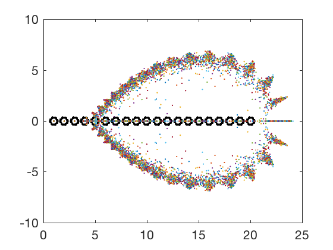

```matlab
p = poly(1:20);
plot(1:20,0,'ko'), hold on
for k = 1:500
   q = p.*(1+1e-9*randn(size(p)));  % relative perturbations
   r = roots(q);
   plot(real(r),imag(r),'.')
end
```

Clearly, having roots close together is not the only way to get sensitivity in the roots. In fact we can't accurately compute the roots even without perturbation to the data:

```matlab
roots(p)
```

```
ans =

  20.000025067150030
  18.999711616114300
  18.001325588115538
  16.996775933863130
  16.004118811901026
  14.998789417426167
  13.994662465567782
  13.011037500812872
  11.987895363460201
  11.008916691876841
   9.995371923454529
   9.001777036204514
   7.999506222071467
   7.000098926981961
   5.999986252392936
   5.000001246518829
   3.999999934630949
   3.000000001450744
   2.000000000006418
   0.999999999999694
```

## Matrix condition number

We have particular interest in the condition number of the problem "given square matrix $A$ and vector $b$, find vector $x$ such that $Ax=b$." More simply: "map $b$ to $A^{-1}b$." The relative condition number of this problem is bounded above by the *matrix condition number* $\kappa(A)=\|A\|\,\|A^{-1}\|$. Furthermore, in any particular case there exist perturbations to the data such that the upper bound is achieved.

```matlab
format short e
A = hilb(5);  kappa = cond(A)
```

```
kappa =

   4.7661e+05
```

The importance of *relative* condition numbers is that they explain accuracy in dimensionless terms, i.e. significant digits. This condition number says we could "lose" up to 5 or so digits in the passage from data to result. So we make relative perturbations to $b$ and see the relative effect on the result.

```matlab
perturb = @(z,ep) z.*(1 + ep*(2*rand(size(z))-1));
x = 0.3+(1:5)';  b = A*x;
bound = 1e-10*kappa
for k = 1:8
    bb = perturb(b,1e-10);
    fprintf(' relative error = %.2e\n', norm( A\bb - x ) / norm( x ) )
end
```

```
bound =

   4.7661e-05

 relative error = 6.83e-07
 relative error = 7.47e-08
 relative error = 6.05e-06
 relative error = 8.56e-06
 relative error = 1.31e-06
 relative error = 4.15e-06
 relative error = 1.23e-07
 relative error = 4.04e-06
```

The same holds for perturbations to $A$, though the error has higher-order terms that vanish only in the limit of infinitesimal perturbations.

```matlab
x = 0.3+(1:5)';  b = A*x;
bound = 1e-10*kappa
for k = 1:8
    AA = perturb(A,1e-10);
    fprintf(' relative error = %.2e\n', norm( AA\b - x ) / norm( x ) )
end
```

```
bound =

   4.7661e-05

 relative error = 5.39e-07
 relative error = 1.03e-06
 relative error = 2.32e-06
 relative error = 1.99e-07
 relative error = 5.80e-06
 relative error = 2.40e-08
 relative error = 7.13e-07
 relative error = 6.53e-07
```